# PIGAL - Analyse PLS multiblocs suivie d’une classification k-means des variables respiratoires

2025-03-14

**Packages**

```r
# chargement des packages nécessaires pour la suite
rm(list=ls())
library(fastDummies)
library(ade4)
library(factoextra)
library(cluster)
library(knitr)
library(table1)
library(FactoMineR)
library(dplyr)
library(writexl)
library(adegraphics)
library(dbscan)
```

**Charger les données**

## _______________________________________________________________________________

#Analyse multiblocs - 21 variables X et une variable Y

## _______________________________________________________________________________

data.clean = fichier contenant 21 variables X et une variable Y.

*Etape 1*

On réalise et CODE_ELEVAGEle découpage par les blocs en accord avec le fichier variables_Sujet_22_envoi.xlsx

```r
X01_Logement_Entretien <- data.clean[, c("X22x1_LOC_INF_rec", "X07x1_AN_CONST4_mean_3", "ENG_TROU", "T13_ENG_milieuDegrad.x")]
X02_Alimentation <- data.clean[, c("T10_PS_EauDebi_3", "T10_PS_AlimPoNourrLongpPo", "X09x3_FAB_CROISS_reg_rec")]
X03_Gestion_Maladies <- data.clean[, c("X18x2_ABBTX_PS", "X19x2_ABB_E")]
X04_Biosecurite <- data.clean[, c("X12x2_MAT_PC", "X12x2_MAT1FRLAV_1", "T16_BS_TenueSpeciElev", "X13x2_QUAI_t")]
X05_Facteurs_Infectieux <- data.clean[, c("A03_Pos10sVERS", "A03_PosSeroMyAs", "A03_TxPosSero22sTgReel", "A04_My10Mfloc", "A05_TxPos10sGRIPPEReel")]
X06_Caracteristiques_Generales <- data.clean[, c("X06x1_gene_majo_1_rec", "X25x1_ElvAlterChoiPers", "LR_LRF")]
```

*Etape 2*

Création des dummy (ie binaires) variables avec le package fastDummies. La variable prise en référence correspond à celle dont l’effectif de réponse est le plus élevé.

```r
data <- list(X01_Logement_Entretien, X02_Alimentation, X03_Gestion_Maladies, X04_Biosecurite, X05_Facteurs_Infectieux, X06_Caracteristiques_Generales)

for(i in 1:length(data)){
  df <- data[[i]]
  for(var in names(df)){
    if(is.factor(df[[var]])){
      df <- dummy_cols(df, var, remove_selected_columns = TRUE, remove_most_frequent_dummy = TRUE)
    }
  }
  data[[i]] <- df
}
```

*Etape 3* La variable Y est en 3 modalités donc elle est également recodée en dummy variables selon le code indiqué ci-dessous. Introduction de la variable Y codée en 3 dummy (ie transformation de Y en 3 variables binaires) variables :

```r
dummy_y <- data.frame(y = data.clean$y)

# Create des 3 Y
dummy_y$sain <- as.integer(dummy_y$y == "Sain")
dummy_y$ps_malade <- as.integer(dummy_y$y == "PS_malade")
dummy_y$eng_malade <- as.integer(dummy_y$y == "ENG_malade")

#suppression de y, la variable Y initiale, qui a été récodée en 3 niveaux Y
dummy_y <- dummy_y[,-1]
summary(dummy_y)
```

```
##       sain        ps_malade     eng_malade
##  Min.   :0.00   Min.   :0.0   Min.   :0.00
##  1st Qu.:0.00   1st Qu.:0.0   1st Qu.:0.00
##  Median :0.00   Median :0.0   Median :0.00
##  Mean   :0.32   Mean   :0.3   Mean   :0.38
##  3rd Qu.:1.00   3rd Qu.:1.0   3rd Qu.:1.00
##  Max.   :1.00   Max.   :1.0   Max.   :1.00
```

```r
# Vérifions que la moyenne vaut bien 1
sum(unlist(lapply(dummy_y, mean))) == 1
```

```
## [1] TRUE
```

*Etape 4*

Création d’un bloc pour la variable Y codée en dummy variables.

```r
# on ne prendra pas le plus fréquent ie eng_malade
summary(dummy_y)
```

```
##       sain        ps_malade     eng_malade
##  Min.   :0.00   Min.   :0.0   Min.   :0.00
##  1st Qu.:0.00   1st Qu.:0.0   1st Qu.:0.00
##  Median :0.00   Median :0.0   Median :0.00
##  Mean   :0.32   Mean   :0.3   Mean   :0.38
##  3rd Qu.:1.00   3rd Qu.:1.0   3rd Qu.:1.00
##  Max.   :1.00   Max.   :1.0   Max.   :1.00
```

```r
#création d'un vecteur Y
bloc.Y <- dummy_y[,1:2]

data[[7]] <- bloc.Y
```

*Etape 5*

Renommer les blocs:

```r
new_names <- c("X01_Logement_Entretien", "X02_Alimentation", "X03_Gestion_Maladies", "X04_Biosecurite", "X05_Facteurs_Infectieux", "X06_Caracteristiques_Generales", "Bloc_Y")
names(data) <- new_names
```

*Etape 6*

**PASSAGE à l’analyse mbPLS**

## Préparation des données

```r
Y <- data[[7]]

row.names(Y)<-rownames(data[[1]])
#renommer les lignes du nouveau Y par les numéros des data 1 à 7 car Y prend le code elevage (PIGAL/ELEV/01...) alors que les autres fichiers ont un numéro d'ordre (perte du code_elevage); sans cela le code d'après bloque #à voir si cette étape est nécessaire dans votre code selon la configuration de votre fichier.
dudiY.ergo <- dudi.pca(Y, center = TRUE, scale = TRUE, scannf = FALSE)
ktabX.ergo <- ktab.list.df(data[1:6])
```

## Variabilité cumulé Y

```r
var_expl <- dudiY.ergo$eig / sum(dudiY.ergo$eig) * 100
var_expl
```

```
## [1] 72.45444 27.54556
```

## mbPLS

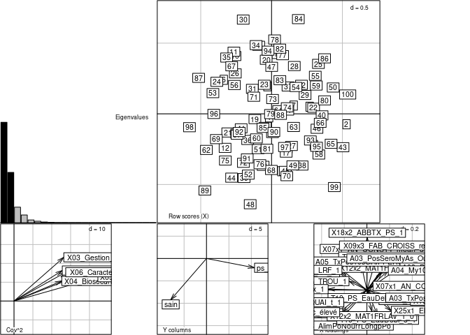

```r
res.mbpls2   <- mbpls(dudiY.ergo, ktabX.ergo, scale = T, option = "uniform", scannf = FALSE, nf = 10)
res.plot     <- plot(res.mbpls2)
```

```r
res.2foldcv2 <- testdim(res.mbpls2, nrepet = 500)  # calcul long
res.2foldcv2
```

```
## Two-fold cross-validation
## Call: testdim.multiblock(object = res.mbpls2, nrepet = 500)
##
## Results for 23 statistics
##
## Root mean square error of calibration:
##      N.rep      Mean       25%       75%
## Ax1    500 0.5910972 0.5807577 0.6005855
## Ax2    500 0.5390479 0.5284830 0.5506001
## Ax3    500 0.5135283 0.5012265 0.5262300
## Ax4    500 0.4939591 0.4807320 0.5079330
## Ax5    500 0.4834812 0.4694005 0.4987124
## Ax6    500 0.4767214 0.4619547 0.4924065
## Ax7    500 0.4731643 0.4574466 0.4891887
## Ax8    500 0.4709594 0.4550985 0.4871106
## Ax9    500 0.4697825 0.4537825 0.4861951
## Ax10   500 0.4690846 0.4529166 0.4856887
## Ax11   500 0.4687056 0.4525480 0.4853196
## Ax12   500 0.4685085 0.4523130 0.4851280
## Ax13   500 0.4684095 0.4522209 0.4850846
## Ax14   500 0.4683612 0.4521673 0.4850611
## Ax15   500 0.4683395 0.4521548 0.4850480
## Ax16   500 0.4683294 0.4521458 0.4850444
## Ax17   499 0.4682845 0.4520110 0.4849179
## Ax18   473 0.4683418 0.4522743 0.4848444
## Ax19   312 0.4671493 0.4508438 0.4836523
## Ax20    77 0.4612720 0.4474129 0.4722521
## Ax21     3 0.4656133 0.4620195 0.4691768
## Ax22     0       NaN        NA        NA
## Ax23     0       NaN        NA        NA
##
## Root mean square error of validation:
##      N.rep      Mean       25%       75%
## Ax1    500 0.6768792 0.6532152 0.7007131
## Ax2    500 0.6577478 0.6285601 0.6843535
## Ax3    500 0.6635662 0.6334621 0.6934613
## Ax4    500 0.6834635 0.6512020 0.7151902
## Ax5    500 0.7016598 0.6670423 0.7350936
## Ax6    500 0.7167772 0.6784840 0.7540545
## Ax7    500 0.7278770 0.6865321 0.7659837
## Ax8    500 0.7359065 0.6927161 0.7739569
## Ax9    500 0.7404844 0.6957943 0.7796429
## Ax10   500 0.7439024 0.6985915 0.7833766
## Ax11   500 0.7457144 0.6991004 0.7854081
## Ax12   500 0.7465001 0.7014618 0.7865992
## Ax13   500 0.7469975 0.7004387 0.7872818
## Ax14   500 0.7471517 0.7005062 0.7872218
## Ax15   500 0.7472570 0.7011949 0.7868075
## Ax16   500 0.7472671 0.7014358 0.7867261
## Ax17   499 0.7473885 0.7018321 0.7866726
## Ax18   473 0.7482693 0.7017856 0.7867890
## Ax19   312 0.7539859 0.7092224 0.7925194
## Ax20    77 0.7756300 0.7246480 0.8231150
## Ax21     3 0.7482790 0.7427804 0.7590463
## Ax22     0       NaN        NA        NA
## Ax23     0       NaN        NA        NA
```

## Variance expliquée par bloc

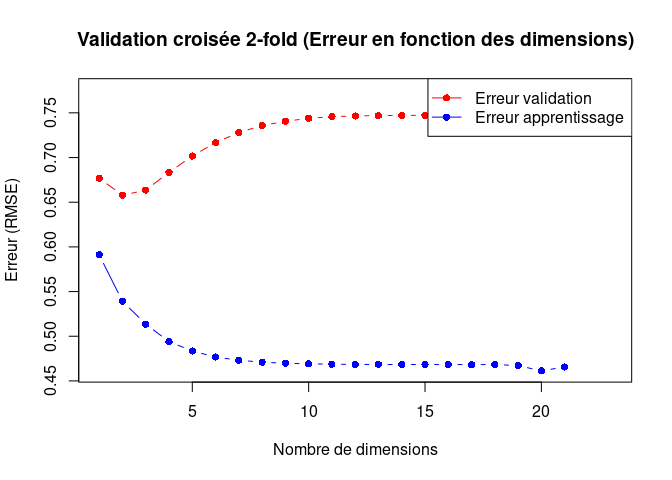

```r
# Remplacer les NaN par NA pour éviter les erreurs
rmsec_values <- res.2foldcv2$statsRMSEc$Mean
rmsec_values[is.nan(rmsec_values)] <- NA

# Définir les limites de l'axe Y pour inclure les deux courbes
ylim_range <- range(c(res.2foldcv2$statsRMSEv$Mean, rmsec_values), na.rm = TRUE)

# Tracer la courbe d'erreur de validation (rouge)
plot(1:23, res.2foldcv2$statsRMSEv$Mean, type = "b", pch = 16, col = "red",
     xlab = "Nombre de dimensions", ylab = "Erreur (RMSE)", ylim = ylim_range,
     main = "Validation croisée 2-fold (Erreur en fonction des dimensions)")

# Ajouter la courbe d'erreur d'apprentissage (bleue)
lines(1:23, rmsec_values, type = "b", pch = 16, col = "blue")

# Ajouter la légende
legend("topright", legend = c("Erreur validation", "Erreur apprentissage"),
       col = c("red", "blue"), pch = 16, lty = 1)
```

NB : les variables X sont centrées et réduites à ce niveau

# Récupération des composantes de tous les axes pour réaliser une classification k-means à partir de ces composantes

```r
#pour les X
recup_compos_X<-res.mbpls2$lX
#pour les Y
recup_compos_Y<-res.mbpls2$lY
```

## Sélection des axes

```
## Multiblock partial least squares
##
## Class: multiblock mbpls
## Call: mbpls(dudiY = dudiY.ergo, ktabX = ktabX.ergo, scale = T, option = "uniform",
##     scannf = FALSE, nf = 10)
##
## Total inertia: 320.1
##
## Eigenvalues:
##     Ax1     Ax2     Ax3     Ax4     Ax5
## 178.761  89.603  27.702  13.774   4.992
##
## Projected inertia (%):
##     Ax1     Ax2     Ax3     Ax4     Ax5
##  55.839  27.989   8.653   4.302   1.559
##
## Cumulative projected inertia (%):
##     Ax1   Ax1:2   Ax1:3   Ax1:4   Ax1:5
##   55.84   83.83   92.48   96.78   98.34
##
## (Only 5 dimensions (out of 23) are shown)
##
## Inertia explained by the global latent, i.e., res.mbpls2$lX (in %):
##
## dudiY.ergo$tab and ktabX.ergo:
##        varY varYcum  varX varXcum
## Ax1  57.468    57.5  8.06    8.06
## Ax2  21.222    78.7 11.38   19.44
## Ax3   8.618    87.3  8.29   27.73
## Ax4   6.503    93.8  5.66   33.39
## Ax5   2.896    96.7  4.74   38.13
## Ax6   1.687    98.4  4.37   42.50
## Ax7   0.677    99.1  5.23   47.73
## Ax8   0.521    99.6  3.89   51.62
## Ax9   0.140    99.7  4.79   56.41
## Ax10  0.166    99.9  3.87   60.28
##
## X01_Logement_Entretien:
##      varXk varXkcum
## Ax1   5.81     5.81
```

[output cut: 173 more lines]

```
## Ax9   5.84    34.42
## Ax10  2.48    36.89
##
## X06_Caracteristiques_Generales:
##      varXk varXkcum
## Ax1   9.10      9.1
## Ax2   5.97     15.1
## Ax3   7.61     22.7
## Ax4   5.19     27.9
## Ax5  15.93     43.8
## Ax6   4.91     48.7
## Ax7  14.89     63.6
## Ax8   2.12     65.7
## Ax9   8.76     74.5
## Ax10  0.41     74.9
```

[output not shown]

[output cut: 59 more lines]

[output not shown]

[output not shown]

[output cut: 59 more lines]

[output not shown]

[output not shown]

[output cut: 59 more lines]

[output not shown]

[output not shown]

[output cut: 59 more lines]

[output not shown]

[output not shown]

[output cut: 59 more lines]

[output not shown]

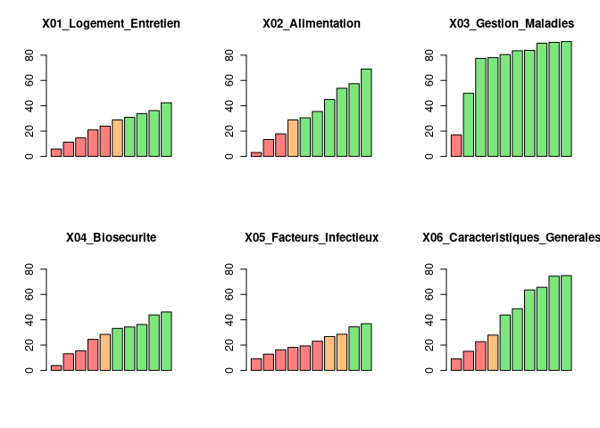

```r
par(mfrow = c(2, 3))
# Def qqc couleurs
red<-rgb(1,0,0,0.5)
orange <- rgb(1, 0.5, 0, 0.5)
green <- rgb(0, 0.8, 0, 0.5)
# Boucle for
for(name in names(invisible(summary(res.mbpls2)))[-1]){
    var.cum <- invisible(summary(res.mbpls2)[[name]][,2])
    color <- ifelse(var.cum <= 25, red, ifelse(var.cum < 30, orange, green))
    barplot(var.cum,
            main=name,
            col = color,
            cex.main=1.25,
            cex.axis=1.2,
            ylim= c(0,87))
}
```

```r
# legend("topright", legend = c("Erreur validation", "Erreur apprentissage"), col = c("red", "blue"), pch = 16, lty = 1)
par(mfrow = c(1, 2))
var.cum <- invisible(summary(res.mbpls2)$YandX[,2])
```

```
## Multiblock partial least squares
##
## Class: multiblock mbpls
## Call: mbpls(dudiY = dudiY.ergo, ktabX = ktabX.ergo, scale = T, option = "uniform",
##     scannf = FALSE, nf = 10)
##
## Total inertia: 320.1
##
## Eigenvalues:
##     Ax1     Ax2     Ax3     Ax4     Ax5
## 178.761  89.603  27.702  13.774   4.992
##
## Projected inertia (%):
##     Ax1     Ax2     Ax3     Ax4     Ax5
##  55.839  27.989   8.653   4.302   1.559
##
## Cumulative projected inertia (%):
##     Ax1   Ax1:2   Ax1:3   Ax1:4   Ax1:5
##   55.84   83.83   92.48   96.78   98.34
##
## (Only 5 dimensions (out of 23) are shown)
##
## Inertia explained by the global latent, i.e., res.mbpls2$lX (in %):
##
## dudiY.ergo$tab and ktabX.ergo:
##        varY varYcum  varX varXcum
## Ax1  57.468    57.5  8.06    8.06
## Ax2  21.222    78.7 11.38   19.44
## Ax3   8.618    87.3  8.29   27.73
## Ax4   6.503    93.8  5.66   33.39
## Ax5   2.896    96.7  4.74   38.13
## Ax6   1.687    98.4  4.37   42.50
## Ax7   0.677    99.1  5.23   47.73
## Ax8   0.521    99.6  3.89   51.62
## Ax9   0.140    99.7  4.79   56.41
## Ax10  0.166    99.9  3.87   60.28
##
## X01_Logement_Entretien:
##      varXk varXkcum
## Ax1   5.81     5.81
```

[output cut: 59 more lines]

```
## Ax9   5.84    34.42
## Ax10  2.48    36.89
##
## X06_Caracteristiques_Generales:
##      varXk varXkcum
## Ax1   9.10      9.1
## Ax2   5.97     15.1
## Ax3   7.61     22.7
## Ax4   5.19     27.9
## Ax5  15.93     43.8
## Ax6   4.91     48.7
## Ax7  14.89     63.6
## Ax8   2.12     65.7
## Ax9   8.76     74.5
## Ax10  0.41     74.9
```

```r
color <- ifelse(var.cum <= 25, red, ifelse(var.cum < 30, orange, green))

barplot(var.cum,
            main="Y",
            col = color,
            cex.main=1.25,
            cex.axis=1.2,
            ylim= c(0,100))
var.cum <- invisible(summary(res.mbpls2)$YandX[,4])
```

```
## Multiblock partial least squares
##
## Class: multiblock mbpls
## Call: mbpls(dudiY = dudiY.ergo, ktabX = ktabX.ergo, scale = T, option = "uniform",
##     scannf = FALSE, nf = 10)
##
## Total inertia: 320.1
##
## Eigenvalues:
##     Ax1     Ax2     Ax3     Ax4     Ax5
## 178.761  89.603  27.702  13.774   4.992
##
## Projected inertia (%):
##     Ax1     Ax2     Ax3     Ax4     Ax5
##  55.839  27.989   8.653   4.302   1.559
##
## Cumulative projected inertia (%):
##     Ax1   Ax1:2   Ax1:3   Ax1:4   Ax1:5
##   55.84   83.83   92.48   96.78   98.34
##
## (Only 5 dimensions (out of 23) are shown)
##
## Inertia explained by the global latent, i.e., res.mbpls2$lX (in %):
##
## dudiY.ergo$tab and ktabX.ergo:
##        varY varYcum  varX varXcum
## Ax1  57.468    57.5  8.06    8.06
## Ax2  21.222    78.7 11.38   19.44
## Ax3   8.618    87.3  8.29   27.73
## Ax4   6.503    93.8  5.66   33.39
## Ax5   2.896    96.7  4.74   38.13
## Ax6   1.687    98.4  4.37   42.50
## Ax7   0.677    99.1  5.23   47.73
## Ax8   0.521    99.6  3.89   51.62
## Ax9   0.140    99.7  4.79   56.41
## Ax10  0.166    99.9  3.87   60.28
##
## X01_Logement_Entretien:
##      varXk varXkcum
## Ax1   5.81     5.81
```

[output cut: 59 more lines]

```
## Ax9   5.84    34.42
## Ax10  2.48    36.89
##
## X06_Caracteristiques_Generales:
##      varXk varXkcum
## Ax1   9.10      9.1
## Ax2   5.97     15.1
## Ax3   7.61     22.7
## Ax4   5.19     27.9
## Ax5  15.93     43.8
## Ax6   4.91     48.7
## Ax7  14.89     63.6
## Ax8   2.12     65.7
## Ax9   8.76     74.5
## Ax10  0.41     74.9
```

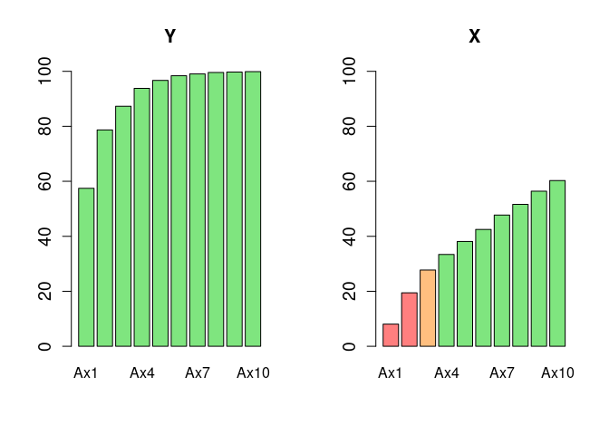

```r
color <- ifelse(var.cum <= 25, red, ifelse(var.cum < 30, orange, green))

barplot(var.cum,
            main="X",
            col = color,
            cex.main=1.25,
            cex.axis=1.2,
            ylim= c(0,100))
```

Afin d’avoir une variabilité cumulé pour la partie des variables X d’au moins de 25-30%, il faudrait garder 3 axes.

## K-means

L’objectif de cette approche est de regarder si de l’hétérogénéité existe au sein des niveaux de Y et que cela s’explique par des pratiques associées qui sont différentes.

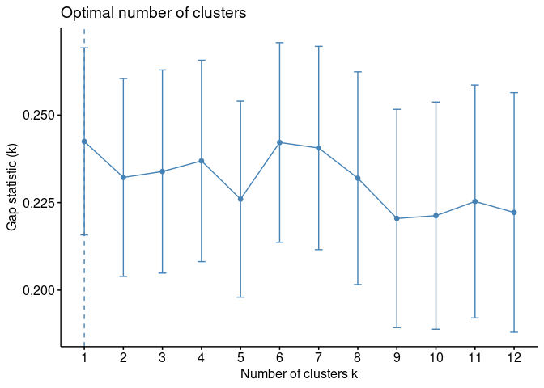

```r
selection_dimensions <- function(res.mbpls, n_dim){
  #composantes du bloc X
  data_clust <- res.mbpls[,c(1:n_dim)] #x premières composantes récupérées pour la suite de la classification
  data_clust.scaled <- scale(data_clust) # centrer

  #calculate gap statistic based on number of clusters
  gap_stat <- clusGap(data_clust.scaled,
                      FUN = kmeans,
                      nstart = 25,
                      K.max = 12,
                      B = 150)

  #plot number of clusters vs. gap statistic
  return(fviz_gap_stat(gap_stat))
}

selection_dimensions(recup_compos_X, 3)
```

### Analyse 3 clusters

```
## $res.km
## K-means clustering with 3 clusters of sizes 33, 38, 29
##
## Cluster means:
##          Ax1        Ax2        Ax3
## 1 -0.3010546  1.1241486  0.3315556
## 2  0.8098904 -0.2651615 -0.5978089
## 3 -0.7186563 -0.9317506  0.4060483
##
## Clustering vector:
##   1   2   3   4   5   6   7   8   9  10  11  12  13  14  15  16  17  18  19  20
##   2   2   1   2   3   1   2   2   1   1   1   3   3   1   1   3   3   3   3   1
##  21  22  23  24  25  26  27  28  29  30  31  32  33  34  35  36  37  38  39  40
##   3   2   1   1   2   1   2   1   2   1   1   1   3   1   1   3   1   2   3   2
##  41  42  43  44  45  46  47  48  49  50  51  52  53  54  55  56  57  58  59  60
##   2   2   2   3   2   2   1   3   2   2   3   3   1   1   2   1   3   2   1   3
##  61  62  63  64  65  66  67  68  69  70  71  72  73  74  75  76  77  78  79  80
##   2   3   2   2   2   2   1   3   3   3   1   3   2   2   3   3   1   1   2   2
##  81  82  83  84  85  86  87  88  89  90  91  92  93  94  95  96  97  98  99 100
##   2   1   1   1   2   1   1   2   3   2   3   3   2   1   2   3   2   3   2   2
##
## Within cluster sum of squares by cluster:
## [1] 45.00175 69.49697 48.06761
##  (between_SS / total_SS =  45.3 %)
##
## Available components:
##
## [1] "cluster"      "centers"      "totss"        "withinss"     "tot.withinss"
## [6] "betweenss"    "size"         "iter"         "ifault"
##
## $plot.km
```

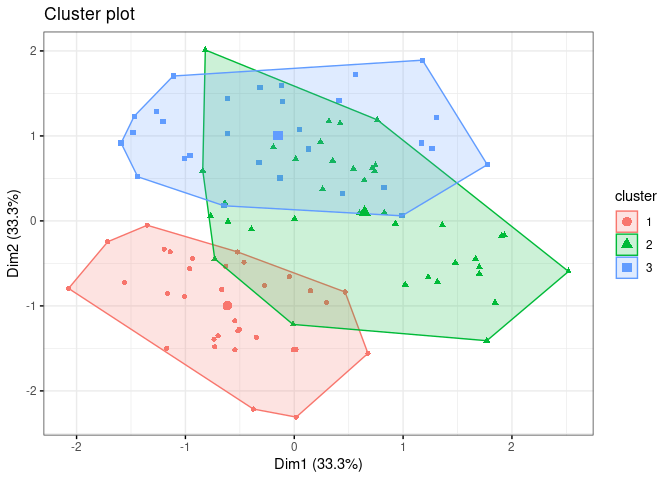

```
##
## $res.table
##
##
## |                          |1                 |2                 |3                 |Overall           |
## |:-------------------------|:-----------------|:-----------------|:-----------------|:-----------------|
## |                          |(N=33)            |(N=38)            |(N=29)            |(N=100)           |
## |X09x3_FAB_CROISS_reg_rec  |                  |                  |                  |                  |
## |0                         |14 (42.4%)        |18 (47.4%)        |23 (79.3%)        |55 (55.0%)        |
## |1                         |19 (57.6%)        |20 (52.6%)        |6 (20.7%)         |45 (45.0%)        |
## |X22x1_LOC_INF_rec         |                  |                  |                  |                  |
## |0                         |18 (54.5%)        |25 (65.8%)        |13 (44.8%)        |56 (56.0%)        |
## |1                         |15 (45.5%)        |13 (34.2%)        |16 (55.2%)        |44 (44.0%)        |
## |X06x1_gene_majo_1_rec     |                  |                  |                  |                  |
## |0                         |8 (24.2%)         |8 (21.1%)         |5 (17.2%)         |21 (21.0%)        |
## |1                         |25 (75.8%)        |30 (78.9%)        |24 (82.8%)        |79 (79.0%)        |
## |X12x2_MAT_PC              |                  |                  |                  |                  |
## |1                         |8 (24.2%)         |14 (36.8%)        |14 (48.3%)        |36 (36.0%)        |
## |2                         |25 (75.8%)        |24 (63.2%)        |15 (51.7%)        |64 (64.0%)        |
## |T10_PS_EauDebi_3          |                  |                  |                  |                  |
## |0                         |17 (51.5%)        |15 (39.5%)        |10 (34.5%)        |42 (42.0%)        |
## |1                         |9 (27.3%)         |14 (36.8%)        |16 (55.2%)        |39 (39.0%)        |
## |2                         |7 (21.2%)         |9 (23.7%)         |3 (10.3%)         |19 (19.0%)        |
## |X12x2_MAT1FRLAV_1         |                  |                  |                  |                  |
## |0                         |3 (9.1%)          |11 (28.9%)        |13 (44.8%)        |27 (27.0%)        |
## |1                         |12 (36.4%)        |12 (31.6%)        |13 (44.8%)        |37 (37.0%)        |
## |2                         |18 (54.5%)        |15 (39.5%)        |3 (10.3%)         |36 (36.0%)        |
## |X07x1_AN_CONST4_mean_3    |                  |                  |                  |                  |
## |0                         |8 (24.2%)         |12 (31.6%)        |13 (44.8%)        |33 (33.0%)        |
## |1                         |13 (39.4%)        |9 (23.7%)         |3 (10.3%)         |25 (25.0%)        |
## |2                         |12 (36.4%)        |17 (44.7%)        |13 (44.8%)        |42 (42.0%)        |
## |T16_BS_TenueSpeciElev     |                  |                  |                  |                  |
## |0                         |9 (27.3%)         |9 (23.7%)         |1 (3.4%)          |19 (19.0%)        |
## |1                         |24 (72.7%)        |29 (76.3%)        |28 (96.6%)        |81 (81.0%)        |
## |X13x2_QUAI_t              |                  |                  |                  |                  |
## |0                         |22 (66.7%)        |20 (52.6%)        |10 (34.5%)        |52 (52.0%)        |
## |1                         |11 (33.3%)        |18 (47.4%)        |19 (65.5%)        |48 (48.0%)        |
## |ENG_TROU                  |                  |                  |                  |                  |
## |0                         |13 (39.4%)        |33 (86.8%)        |24 (82.8%)        |70 (70.0%)        |
## |1                         |20 (60.6%)        |5 (13.2%)         |5 (17.2%)         |30 (30.0%)        |
```

[output cut: 87 more lines]

```
## A03_Pos10sVERS=0           36.923077 82.758621     65 1.710067e-02  2.384536
## A03_PosSeroMyAs=Non        39.215686 68.965517     51 2.383688e-02  2.259748
## X13x2_QUAI_t=1             39.583333 65.517241     48 2.804759e-02  2.196620
## T10_PS_EauDebi_3=1         41.025641 55.172414     39 3.970442e-02  2.056811
## A04_My10Mfloc=modéré       14.285714 13.793103     28 4.297323e-02 -2.023970
## X07x1_AN_CONST4_mean_3=1   12.000000 10.344828     25 2.896466e-02 -2.183967
## X13x2_QUAI_t=0             19.230769 34.482759     52 2.804759e-02 -2.196620
## A03_PosSeroMyAs=Oui        18.367347 31.034483     49 2.383688e-02 -2.259748
## A03_Pos10sVERS=1           14.285714 17.241379     35 1.710067e-02 -2.384536
## X19x2_ABB_E=0              16.279070 24.137931     43 1.566735e-02 -2.416574
## X18x2_ABBTX_PS=1           15.909091 24.137931     44 1.111806e-02 -2.538966
## T16_BS_TenueSpeciElev=0     5.263158  3.448276     19 8.119206e-03 -2.647072
## X09x3_FAB_CROISS_reg_rec=1 13.333333 20.689655     45 1.797760e-03 -3.121756
## X12x2_MAT1FRLAV_1=2         8.333333 10.344828     36 4.387464e-04 -3.515609
## y=ENG_malade                7.894737 10.344828     38 1.764789e-04 -3.750505
```

```r
analyse_clusters <- function(res.mbpls, donnees, n_dim, centers){
  data_clust <- res.mbpls[,c(1:n_dim)] #x premières composantes récupérées pour la suite de la classification
  data_clust.scaled <- scale(data_clust) # centrer


  #perform k-means clustering with k = x clusters (x=centers)
  res.km <- kmeans(data_clust.scaled, centers = centers, nstart = 25)


  #plot results of final k-means model
  resultat.2dim <- fviz_cluster(res.km, data = data_clust.scaled,
              geom = "point",
              ellipse.type = "convex",
              ggtheme = theme_bw()
              )

  data.avec_cl <- cbind(donnees, res.km$cluster)
  nom.clust <- paste0("cluster_km", n_dim)
  names(data.avec_cl) <- c(names(donnees), nom.clust)

  data.avec_clb <-data_frame(data.avec_cl)

  #déclarer la variable cluster_km en facteur
  data.avec_clb[[nom.clust]] <- as.factor(data.avec_clb[[nom.clust]])

  data.table <- kable(table1(as.formula(paste("~ . |", nom.clust)), data = data.avec_clb))

  data.dsc <- catdes(data.avec_clb, num.var = ncol(data.avec_clb), proba =0.05)$category



  cluster_list <- list()
  for (i in 1:centers) {
    cluster_list[[paste("cluster", i, sep = "_")]] <- as.data.frame(data.dsc[[as.character(i)]])
    cluster_list[[paste("cluster", i, sep = "_")]] <- dplyr::as_data_frame(cluster_list[[paste("cluster", i, sep = "_")]], rownames = "Variable")
  }
  file_path <- paste0("mb-pls/Clusters_km", paste0(n_dim, ".xlsx"))
  # write_xlsx(cluster_list, file_path, col_names = TRUE, format_headers = TRUE, use_zip64 = FALSE)

  return(list("res.km"=res.km,
               "plot.km"=resultat.2dim,
               "res.table"=data.table,
               "res.catdes"=data.dsc))

}
res.3.3 <- analyse_clusters(recup_compos_X, data.clean, 3, 3)
res.3.3
```

#### Bloc 1 Élevages avec prédominance d’ENG_malade

Dans ce groupe, 66,7 % des élevages présentent des porcs malades en engraissement (ENG_malade), indiquant une vulnérabilité prononcée au niveau de cette phase de production. On note également une utilisation quasi systématique d’antibiotiques en cas de besoin (X19x2_ABB_E=1 à 93,9 %) et un recours très élevé à l’antibiothérapie contre la toux en post-sevrage (X18x2_ABBTX_PS=1 à 97,0 %). La forte présence de « trou dans la cloison » (ENG_TROU=1 à 60,6 %) suggère que des défaillances structurelles ou une hygiène déficiente pourraient contribuer à la propagation des agents pathogènes, exacerbant ainsi les troubles respiratoires observés en phase d’engraissement.

#### Bloc 2 : Élevages caractérisés par une forte prévalence de PS_malade

Dans ce groupe, les porcs en post-sevrage malades (PS_malade) représentent 50,0 % des cas, indiquant que les troubles respiratoires se manifestent majoritairement dès la phase post-sevrage. Contrairement au Bloc 1, l’utilisation d’antibiotiques est nettement réduite, avec X19x2_ABB_E=1 à seulement 10,5 % et X18x2_ABBTX_PS=1 à 13,2 %. Ce profil pourrait refléter des stratégies de gestion moins axées sur les interventions médicamenteuses, potentiellement en raison d’une moindre détection ou prise en charge des symptômes à ce stade. Par ailleurs, la faible fréquence des défaillances structurelles (ENG_TROU=0 à 86,8 %) suggère que d’autres facteurs, comme la sensibilité intrinsèque des porcs post-sevrage ou des pratiques d’élevage spécifiques, pourraient être en jeu dans l’augmentation des cas de PS_malade.

#### Bloc 3 : Élevages avec prédominance d’animaux sains

Ce groupe se distingue par une très forte proportion d’animaux sains (72,4 %), accompagnée d’une faible incidence des troubles respiratoires en engraissement (10,3 % ENG_malade) et en post-sevrage (17,2 % PS_malade). Ces élevages semblent bénéficier de meilleures conditions d’élevage et d’une gestion sanitaire plus efficace, comme en témoigne la moindre utilisation d’antibiotiques contre la toux (X18x2_ABBTX_PS=1 à 24,1 %) et une présence réduite de problèmes structurels (ENG_TROU=1 à seulement 17,2 %). L’ensemble de ces indicateurs souligne l’importance d’un environnement bien entretenu et d’une approche préventive dans la réduction des troubles respiratoires, permettant ainsi d’optimiser la santé et la performance des élevages.

### Analyse 5 clusters

```r
res.3.5 <- analyse_clusters(recup_compos_X, data.clean, 3, 5)
res.3.5
```

```
## $res.km
## K-means clustering with 5 clusters of sizes 12, 18, 14, 28, 28
##
## Cluster means:
##          Ax1        Ax2        Ax3
## 1 -1.0780177 -1.0222287 -0.7862628
## 2 -0.5442736 -0.7552760  1.1006149
## 3  0.5848416  0.1090374 -1.6032712
## 4  1.0058118 -0.3237654  0.2734918
## 5 -0.4863348  1.1928793  0.1575754
##
## Clustering vector:
##   1   2   3   4   5   6   7   8   9  10  11  12  13  14  15  16  17  18  19  20
##   3   4   5   4   2   5   4   4   5   5   5   2   4   5   5   2   2   2   2   5
##  21  22  23  24  25  26  27  28  29  30  31  32  33  34  35  36  37  38  39  40
##   2   4   5   5   4   5   4   5   3   5   5   4   2   5   5   2   5   4   1   4
##  41  42  43  44  45  46  47  48  49  50  51  52  53  54  55  56  57  58  59  60
##   1   3   4   2   4   4   5   1   4   4   2   2   5   4   3   5   2   4   4   2
##  61  62  63  64  65  66  67  68  69  70  71  72  73  74  75  76  77  78  79  80
##   3   1   3   3   4   3   5   2   1   4   2   1   3   3   1   1   5   5   3   3
##  81  82  83  84  85  86  87  88  89  90  91  92  93  94  95  96  97  98  99 100
##   1   5   5   5   3   4   5   4   1   4   2   1   4   5   4   2   4   1   4   3
##
## Within cluster sum of squares by cluster:
## [1] 11.88351 14.72892 11.34620 37.45166 28.82354
##  (between_SS / total_SS =  64.9 %)
##
## Available components:
##
## [1] "cluster"      "centers"      "totss"        "withinss"     "tot.withinss"
## [6] "betweenss"    "size"         "iter"         "ifault"
##
## $plot.km
```

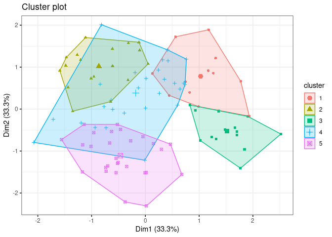

```
##
## $res.table
##
##
## |                          |1                 |2                 |3                 |4                 |5                 |Overall           |
## |:-------------------------|:-----------------|:-----------------|:-----------------|:-----------------|:-----------------|:-----------------|
## |                          |(N=12)            |(N=18)            |(N=14)            |(N=28)            |(N=28)            |(N=100)           |
## |X09x3_FAB_CROISS_reg_rec  |                  |                  |                  |                  |                  |                  |
## |0                         |9 (75.0%)         |15 (83.3%)        |7 (50.0%)         |12 (42.9%)        |12 (42.9%)        |55 (55.0%)        |
## |1                         |3 (25.0%)         |3 (16.7%)         |7 (50.0%)         |16 (57.1%)        |16 (57.1%)        |45 (45.0%)        |
## |X22x1_LOC_INF_rec         |                  |                  |                  |                  |                  |                  |
## |0                         |7 (58.3%)         |6 (33.3%)         |13 (92.9%)        |12 (42.9%)        |18 (64.3%)        |56 (56.0%)        |
## |1                         |5 (41.7%)         |12 (66.7%)        |1 (7.1%)          |16 (57.1%)        |10 (35.7%)        |44 (44.0%)        |
## |X06x1_gene_majo_1_rec     |                  |                  |                  |                  |                  |                  |
## |0                         |5 (41.7%)         |1 (5.6%)          |7 (50.0%)         |0 (0%)            |8 (28.6%)         |21 (21.0%)        |
## |1                         |7 (58.3%)         |17 (94.4%)        |7 (50.0%)         |28 (100%)         |20 (71.4%)        |79 (79.0%)        |
## |X12x2_MAT_PC              |                  |                  |                  |                  |                  |                  |
## |1                         |7 (58.3%)         |7 (38.9%)         |5 (35.7%)         |10 (35.7%)        |7 (25.0%)         |36 (36.0%)        |
## |2                         |5 (41.7%)         |11 (61.1%)        |9 (64.3%)         |18 (64.3%)        |21 (75.0%)        |64 (64.0%)        |
## |T10_PS_EauDebi_3          |                  |                  |                  |                  |                  |                  |
## |0                         |5 (41.7%)         |6 (33.3%)         |6 (42.9%)         |10 (35.7%)        |15 (53.6%)        |42 (42.0%)        |
## |1                         |3 (25.0%)         |11 (61.1%)        |4 (28.6%)         |13 (46.4%)        |8 (28.6%)         |39 (39.0%)        |
## |2                         |4 (33.3%)         |1 (5.6%)          |4 (28.6%)         |5 (17.9%)         |5 (17.9%)         |19 (19.0%)        |
## |X12x2_MAT1FRLAV_1         |                  |                  |                  |                  |                  |                  |
## |0                         |3 (25.0%)         |10 (55.6%)        |3 (21.4%)         |9 (32.1%)         |2 (7.1%)          |27 (27.0%)        |
## |1                         |7 (58.3%)         |7 (38.9%)         |5 (35.7%)         |8 (28.6%)         |10 (35.7%)        |37 (37.0%)        |
## |2                         |2 (16.7%)         |1 (5.6%)          |6 (42.9%)         |11 (39.3%)        |16 (57.1%)        |36 (36.0%)        |
## |X07x1_AN_CONST4_mean_3    |                  |                  |                  |                  |                  |                  |
## |0                         |3 (25.0%)         |8 (44.4%)         |4 (28.6%)         |11 (39.3%)        |7 (25.0%)         |33 (33.0%)        |
## |1                         |2 (16.7%)         |2 (11.1%)         |7 (50.0%)         |4 (14.3%)         |10 (35.7%)        |25 (25.0%)        |
## |2                         |7 (58.3%)         |8 (44.4%)         |3 (21.4%)         |13 (46.4%)        |11 (39.3%)        |42 (42.0%)        |
## |T16_BS_TenueSpeciElev     |                  |                  |                  |                  |                  |                  |
## |0                         |0 (0%)            |1 (5.6%)          |4 (28.6%)         |6 (21.4%)         |8 (28.6%)         |19 (19.0%)        |
## |1                         |12 (100%)         |17 (94.4%)        |10 (71.4%)        |22 (78.6%)        |20 (71.4%)        |81 (81.0%)        |
## |X13x2_QUAI_t              |                  |                  |                  |                  |                  |                  |
## |0                         |1 (8.3%)          |10 (55.6%)        |8 (57.1%)         |15 (53.6%)        |18 (64.3%)        |52 (52.0%)        |
## |1                         |11 (91.7%)        |8 (44.4%)         |6 (42.9%)         |13 (46.4%)        |10 (35.7%)        |48 (48.0%)        |
## |ENG_TROU                  |                  |                  |                  |                  |                  |                  |
## |0                         |8 (66.7%)         |14 (77.8%)        |13 (92.9%)        |25 (89.3%)        |10 (35.7%)        |70 (70.0%)        |
## |1                         |4 (33.3%)         |4 (22.2%)         |1 (7.1%)          |3 (10.7%)         |18 (64.3%)        |30 (30.0%)        |
```

[output cut: 103 more lines]

```
## X18x2_ABBTX_PS=1         61.363636 96.428571     44 7.855712e-12  6.841155
## X19x2_ABB_E=1            47.368421 96.428571     57 1.267135e-07  5.283537
## y=ENG_malade             55.263158 75.000000     38 3.420867e-06  4.643783
## ENG_TROU=1               60.000000 64.285714     30 8.406119e-06  4.454571
## LR_LRF=1                 62.500000 35.714286     16 2.019916e-03  3.087288
## X12x2_MAT1FRLAV_1=2      44.444444 57.142857     36 8.018263e-03  2.651300
## T13_ENG_milieuDegrad.x=1 38.775510 67.857143     49 2.090606e-02  2.309677
## T13_ENG_milieuDegrad.x=0 17.647059 32.142857     51 2.090606e-02 -2.309677
## y=Sain                   12.500000 14.285714     32 1.702852e-02 -2.386091
## y=PS_malade              10.000000 10.714286     30 7.417704e-03 -2.677486
## X12x2_MAT1FRLAV_1=0       7.407407  7.142857     27 3.864307e-03 -2.889031
## LR_LRF=0                 21.428571 64.285714     84 2.019916e-03 -3.087288
## ENG_TROU=0               14.285714 35.714286     70 8.406119e-06 -4.454571
## X19x2_ABB_E=0             2.325581  3.571429     43 1.267135e-07 -5.283537
## X18x2_ABBTX_PS=0          1.785714  3.571429     56 7.855712e-12 -6.841155
```

#### Bloc A : Élevages avec prédominance d’ENG_malade

Dans ce bloc, représenté par les groupes 3 et 5, la majorité des élevages présente une forte proportion de porcs malades en engraissement (71,4 % et 75,0 % respectivement). Ce constat souligne une vulnérabilité marquée en phase d’engraissement. L’analyse des pratiques révèle des contrastes intéressants entre les deux groupes de ce bloc, notamment en ce qui concerne l’usage des antibiotiques. Par exemple, dans le groupe 3, l’absence quasi totale d’utilisation d’antibiotiques (X19x2_ABB_E : 100 % de 0 et X18x2_ABBTX_PS : 100 % de 0) contraste fortement avec le groupe 5 où l’utilisation est presque systématique (X19x2_ABB_E : 96,4 % de 1 et X18x2_ABBTX_PS : 96,4 % de 1). Ces divergences suggèrent que, malgré une prédisposition similaire à des troubles respiratoires en engraissement, les stratégies thérapeutiques et de gestion peuvent différer, influençant possiblement l’évolution de la maladie.

#### Bloc B : Élevages avec prédominance de PS_malade

Ce bloc est caractérisé par le groupe 4, où les porcs malades en post-sevrage représentent 67,9 % des élevages, indiquant une incidence élevée de troubles respiratoires dès la période post-sevrage. Dans ce groupe, la proportion d’animaux malades en engraissement reste relativement faible (14,3 %), tandis que la minorité d’animaux sains (17,9 %) met en lumière une problématique spécifique à ce stade. Les indicateurs de pratiques d’élevage, tels que l’uniformité de la génétique (X06x1_gene_majo_1_rec : 100 % de 1) et une répartition équilibrée de certaines mesures d’hygiène ou d’infrastructure (par exemple, T10_PS_EauDebi_3 et X12x2_MAT1FRLAV_1), suggèrent que des facteurs propres au sevrage – et non à l’engraissement – pourraient être à l’origine de la forte prévalence de PS_malade dans ce groupe.

## Hdbscan

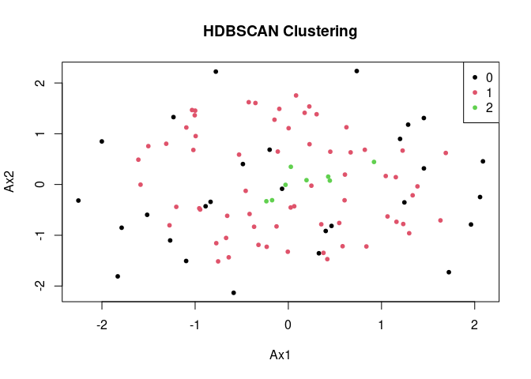

```r
clasif.hdbscan <- function(res.mbpls, n_dim) {
  # Extract the first n_dim components from the res.mbpls object
  data_clust <- res.mbpls[, c(1:n_dim)]
  data_clust.scaled <- scale(data_clust)  # Scale the data

  # Apply HDBSCAN clustering
  hdbscan_result <- hdbscan(data_clust.scaled, minPts = 5)  # minPts is a key parameter for HDBSCAN

  # Visualize the clustering results
  plot(data_clust.scaled, col = hdbscan_result$cluster + 1, pch = 20, main = "HDBSCAN Clustering")
  legend("topright", legend = unique(hdbscan_result$cluster), col = unique(hdbscan_result$cluster + 1), pch = 20)

  # Return the HDBSCAN result for further inspection
  return(hdbscan_result)
}
res.hdb <- clasif.hdbscan(recup_compos_X, 3)
```

```r
res.hdb
```

```
## HDBSCAN clustering for 100 objects.
## Parameters: minPts = 5
## The clustering contains 2 cluster(s) and 28 noise points.
##
##  0  1  2
## 28 64  8
##
## Available fields: cluster, minPts, coredist, cluster_scores,
##                   membership_prob, outlier_scores, hc
```

Pour des clusters avec au moins 5 individus, on obtient 2 cluster, 28 élevages ne sont pas classées et 64 sont dans le même cluster, on n’utilisera donc pas cette méthode par manque de généralisation.